# Markdown demonstration - HTML format

Julia Müller

21 April 2022

# 1 Preparation

## 1.1 Choosing the data

As everyone always says,

> penguins are very cute!

…so let’s work with penguin data today.

More information on this data set is available on [Allison Horst’s Github page.](https://allisonhorst.github.io/palmerpenguins/)

This data can also be used via the {palmerpenguins} package (Horst et al., 2020) and was originally introduced in Gorman et al. (2014)

## 1.2 Loading packages & reading data

First, we need to:  
1. load **packages**  
2. read in **data**  
3. check if that data is *in the right format*

```r
library(tidyverse)
penguins <- read_csv('https://raw.githubusercontent.com/rfordatascience/tidytuesday/master/data/2020/2020-07-28/penguins.csv') %>%
  drop_na()
head(penguins)
```

```
## # A tibble: 6 x 8
##   species island bill_length_mm bill_depth_mm flipper_length_~ body_mass_g sex
##   <chr>   <chr>           <dbl>         <dbl>            <dbl>       <dbl> <chr>
## 1 Adelie  Torge~           39.1          18.7              181        3750 male
## 2 Adelie  Torge~           39.5          17.4              186        3800 fema~
## 3 Adelie  Torge~           40.3          18                195        3250 fema~
## 4 Adelie  Torge~           36.7          19.3              193        3450 fema~
## 5 Adelie  Torge~           39.3          20.6              190        3650 male
## 6 Adelie  Torge~           38.9          17.8              181        3625 fema~
## # ... with 1 more variable: year <dbl>
```

We’ve removed missing values here, which means that the data has 333 rows now.

## 1.3 Some descriptive statistics

The average bill length is 43.9927928 mm and the average bill depth is 17.1648649 mm.  
The data was collected between 2007 and 2009.

# 2 Graphs

Some ideas for graphs:

- penguin weight by flipper length
  - for the entire data
  - or separately for each species
  - and additionally by sex
- flipper and bill length
- bill length and depth

## 2.1 Weight and flipper length

The following graphs are slightly simplified versions from the [vignette for the {palmerpenguins} package.](https://allisonhorst.github.io/palmerpenguins/articles/examples.html)

### 2.1.1 Entire data

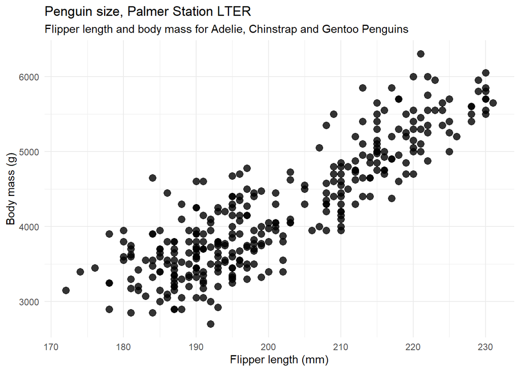

```r
mass_flipper <- ggplot(data = penguins,
                       aes(x = flipper_length_mm,
                           y = body_mass_g)) +
  geom_point(size = 3,
             alpha = 0.8) +
  theme_minimal() +
  labs(title = "Penguin size, Palmer Station LTER",
       subtitle = "Flipper length and body mass for Adelie, Chinstrap and Gentoo Penguins",
       x = "Flipper length (mm)",
       y = "Body mass (g)") +
  theme_minimal()

mass_flipper
```

### 2.1.2 Separated by species

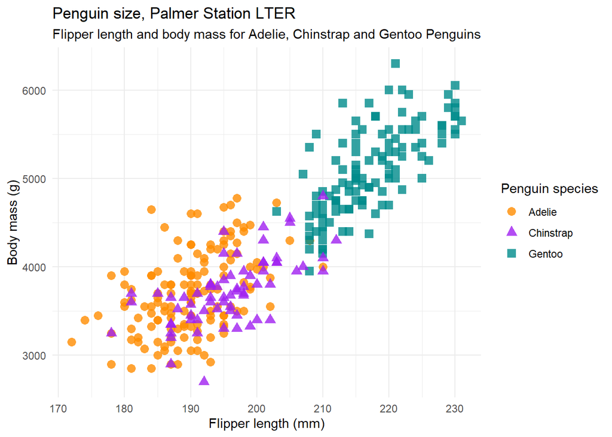

```r
mass_flipper_species <- ggplot(data = penguins,
                       aes(x = flipper_length_mm,
                           y = body_mass_g)) +
  geom_point(aes(color = species,
                 shape = species),
             size = 3,
             alpha = 0.8) +
  theme_minimal() +
  scale_color_manual(values = c("darkorange","purple","cyan4")) +
  labs(title = "Penguin size, Palmer Station LTER",
       subtitle = "Flipper length and body mass for Adelie, Chinstrap and Gentoo Penguins",
       x = "Flipper length (mm)",
       y = "Body mass (g)",
       color = "Penguin species",
       shape = "Penguin species") +
  theme_minimal()

mass_flipper_species
```

### 2.1.3 Separated by species and sex

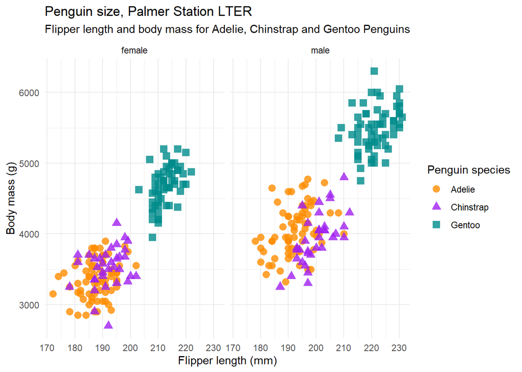

```r
mass_flipper_species +
  facet_wrap(~sex)
```

# References

Gorman, K. B., Williams, T. D., & Fraser, W. R. (2014). Ecological sexual dimorphism and environmental variability within a community of antarctic penguins (genus pygoscelis). *PloS One*, *9*(3), e90081. https://doi.org/10.1371/journal.pone.0090081

Horst, A. M., Presmanes Hill, A., & Gorman, K. B. (2020). *Palmerpenguins: Palmer archipelago (antarctica) penguin data. R package version 0.1.0.* Zenodo. https://doi.org/10.5281/zenodo.3960218